# Porównanie intuicyjnego szacowania wartości procentowych na wykresach kołowych i słupkowych

2022-11-24

## Wstęp

Jedną z najważniejszych cech wykresów jest możliwość szybkiego przyswojenia ich przekazu - nierzadko adresat “rzuca okiem” na jego “kolorową” część pomijając przydatne informacje zawarte w etykietach, opisach czy znacznikach osi. Twórcy wykresów przystosowują się do optymalizując przekaz informacji płynący z samej geometrii wykresu. Poniżej zbadano, która forma wykresu (słupkowy czy kołowy) lepiej dopełnia tej optymalizacji dla danych przedstawiających podział procentowy.

## Metodologia

Celem przedstawionych poniżej eksperymentów jest sprawdzenie, który typ wykresu (kołowy czy słupkowy) lepiej nadaje się do reprezentacji danych procentowych w sytuacji jedynie pobieżnego ich zanalizowania. Aby to zbadać przygotowano ankietę z 24 pytaniami o to, jaki procent całości danych na wykresie stanowi zaznaczony słupek lub kawałek wykresu. Z każdego użytego zbioru danych utworzono tyle samo wykresów kołowych i słupkowych. Stworzono dwie równe co do liczności grupy wykresów:

1. Pozbawione osi oraz etykiet kawałków/słupków, a więc “czyste” wykresy, gdzie jedynie wizualnie można ocenić wielkości
2. Pozbawione osi, ale zawierające etykietę jednego z kawałków wskazującą na to, jaką część całości zajmuje. Podsumowując, w kwestionariuszu mamy 12 wykresów bez punktu odniesienia i 12 z, z czego w każdej z tych grup jest po 6 wykresów kołowych i słupkowych.

Dane na wszystkich wykresach posortowano malejąco oraz pokolorowano. Pytania w ankietach były podawane losowo, aby zmniejszyć ryzyko domyślenia się przez wypełniającego, że dane wykresy kołowe i słupkowe są ze sobą tożsame. W przypadku wykresów bez punktu odniesienia dla każdej pary wykresów z jednego zbioru danych zadawano pytanie o ten sam kawałek/słupek, a do wykresów z punktem odniesienia zadawano różne pytania przy różnych kawałkach słupkach służących za odniesienie, aby uniknąć zauważenia tożsamości między wykresami.

Wszystkie pytania wraz z danymi oraz identyfikatorem pary znajdują się w pliku wykresy.pdf.

## Wyniki

W celu wizualizacji wyników ankiety obliczono błąd bezwzględny każdej odpowiedzi po czym pominięto każdą odpowiedź, której błąd bezwzględny był większy niż 20 pp.

### Wykresy bez punktu odniesienia

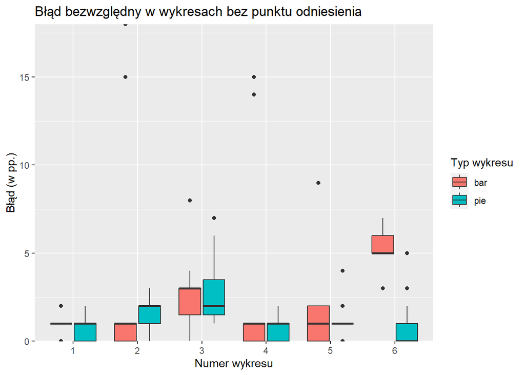

Dla większości par wykresów różnice między kołowym a słupkowym są niewielkie, jednak ogromną różnicę na korzyść wykresu kołowego widać w parze 6, gdzie najdalej wysunięte punkty dla wykresu kołowego są na poziomie mediany błędu wykresu słupkowego. Prawdpodobnie jest to spowodowane dużą liczbą kawałków (9), które utrudniają poprawny odczyt na wykresie słupkowym ze względu na brak odniesienia do całości, jak do całego koła w przypadku wykresu kołowego. Poza tym widzimy też, że największe wartości błędu dla wykresów słupkowych są najczęściej wyższe niż dla kołowych.

### Wykresy z punktem odniesienia

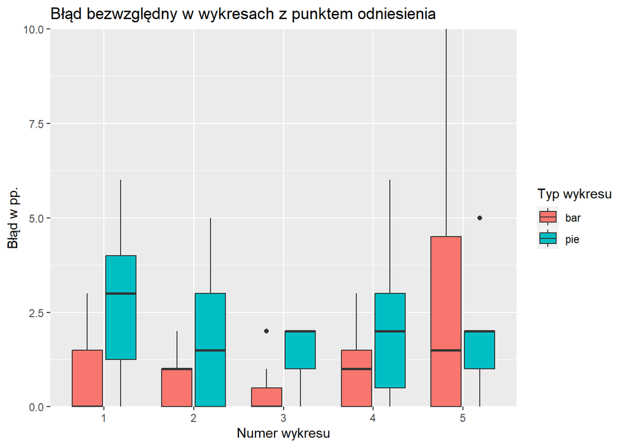

W przypadku wykresów z punktem odniesienia natychmiast widać przewagę wykresów słupkowych, w których, z wyłączeniem pary 5, najwyższa wartość błędu oscyluje w okolicach mediany wartości błędu dla wykresu kołowego. W przypadku wykresu 5 mediana błędu dla wykresów słupkowych nadal jest niższa niż dla kołowych, jednak rozrzut błędów jest znacznie większy.

## Wnioski

Mała próba zaróWno pytań w ankiecie jak i odpowiedzi nie ułatwia wysnuwania rzetelnych wniosków, jednak otrzymane dane wyraźnie wskazują na przewagę wykresu słupkowego, który nie sprawdził się właściwie tylko w przypadku braku punktu odniesienia i podziału na wiele słupków. Wykres kołowy zdaje się być lepszy do reprezentowania danych z wieloma grupami, jednak przy coraz mniejszych pojedynczych kawałkach również powinien tracić on na wartości. W przypadku wykresów z odniesieniem słupkowe prezentowały się lepiej dla każdej pary. Można więc śmiało przypuścić, że kodeks “dobrych praktyk” w kwestii wykresóW kołowych się nie zdezaktualizował.

## Uwagi

1. Przy analizie otrzymanych danych zauważono pomyłkę w postaci złej etykiety słupka w jednej pozycji w ankiecie więc w wynikach pominięto ją, oraz siostrzany wykres kołowy.
2. W wykresach słupkowych użyto kolorów mimo, że jest to wbrew “dobrym praktykom”, zauważono to jednak za późno i stwierdzono, że nie powinno to mieć wpływu na wyniki badań ze względu na i tak bardzo nieabsorbującą uwagi strukturę wykresu.